# 31305_Assignment_2

Name: Vrushaket P. Chaudhari

Roll No: 31305

Class : TE-03

Batch : K3

Subject : DSBDAL

Assignment : 2. Data Wrangling II

## Data Wrangling II

### Perform the following operations using Python on any open source dataset (eg. data.csv)

1. Scan all variables for missing values and inconsistencies. If there are missing values and/or inconsistencies, use any of the suitable techniques to deal with them.
2. Scan all numeric variables for outliers. If there are outliers, use any of the suitable techniques to deal with them.
3. Apply data transformations on at least one of the variables. The purpose of this transformation should be one of the following reasons: to change the scale for better understanding of the variable, to convert a non-linear relation into a linear one, or to decrease the skewness and convert the distribution into a normal distribution.

Reason and document your approach properly

## Import all the required Python Libraries.

```python
import numpy as np
import pandas as pd
import matplotlib.pyplot as plt
import seaborn as sns
%matplotlib inline
```

## Load the Dataset into pandas data frame.

```python
from pandas import read_csv
df = read_csv('StudentsPerformance_modified.csv')
```

```python
df
```

|  | gender | race/ethnicity | parental level of education | lunch | test preparation course | math score | reading score | writing score |
| --- | --- | --- | --- | --- | --- | --- | --- | --- |
| 0 | female | group B | bachelor's degree | standard | none | 72 | 72.0 | 74.0 |
| 1 | female | group C | some college | standard | completed | NaN | 90.0 | 88.0 |
| 2 | female | group B | master's degree | standard | none | 90 | 95.0 | 93.0 |
| 3 | male | group A | associate's degree | free/reduced | none | 47 | 57.0 | 44.0 |
| 4 | male | group C | some college | standard | none | 76 | 78.0 | 75.0 |
| ... | ... | ... | ... | ... | ... | ... | ... | ... |
| 995 | female | group E | master's degree | standard | completed | 88 | 99.0 | 95.0 |
| 996 | male | group C | high school | free/reduced | none | 62 | 55.0 | 55.0 |
| 997 | female | group C | high school | free/reduced | completed | 59 | 71.0 | 65.0 |
| 998 | female | group D | some college | standard | completed | 68 | 78.0 | 77.0 |
| 999 | female | group D | some college | free/reduced | none | 77 | 86.0 | 86.0 |

1000 rows × 8 columns

```python
df.head()
```

|  | gender | race/ethnicity | parental level of education | lunch | test preparation course | math score | reading score | writing score |
| --- | --- | --- | --- | --- | --- | --- | --- | --- |
| 0 | female | group B | bachelor's degree | standard | none | 72 | 72.0 | 74.0 |
| 1 | female | group C | some college | standard | completed | NaN | 90.0 | 88.0 |
| 2 | female | group B | master's degree | standard | none | 90 | 95.0 | 93.0 |
| 3 | male | group A | associate's degree | free/reduced | none | 47 | 57.0 | 44.0 |
| 4 | male | group C | some college | standard | none | 76 | 78.0 | 75.0 |

### 1. Scan all variables for missing values and inconsistencies. If there are missing values and/or inconsistencies, use any of the suitable techniques to deal with them.

```python
df['math score'].dtype
```

```
dtype('O')
```

```python
df = df.replace("?", np.NaN)
df['math score'] = df['math score'].astype('float64')
df['math score']
```

```
0      72.0
1       NaN
2      90.0
3      47.0
4      76.0
       ...
995    88.0
996    62.0
997    59.0
998    68.0
999    77.0
Name: math score, Length: 1000, dtype: float64
```

```python
df.isnull().sum()
```

```
gender                          0
race/ethnicity                  0
parental level of education     0
lunch                           0
test preparation course         0
math score                     44
reading score                   6
writing score                   9
dtype: int64
```

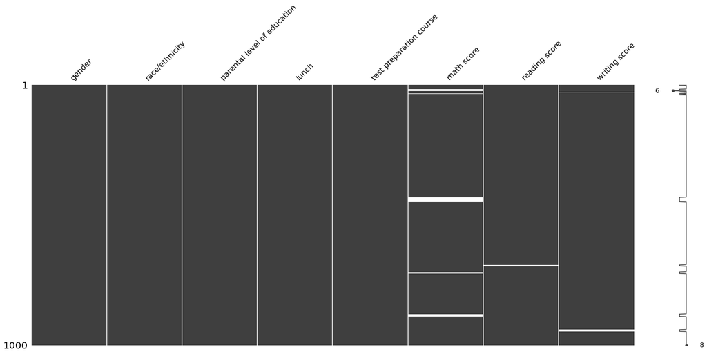

```python
import missingno as msno
msno.matrix(df)
```

```python
df['math score'].replace(np.NaN, df['math score'].median(), inplace=True)
df['reading score'].replace(np.NaN, df['reading score'].median(), inplace=True)
df['writing score'].replace(np.NaN, df['writing score'].median(), inplace=True)
```

```python
df.isnull().sum()
```

```
gender                         0
race/ethnicity                 0
parental level of education    0
lunch                          0
test preparation course        0
math score                     0
reading score                  0
writing score                  0
dtype: int64
```

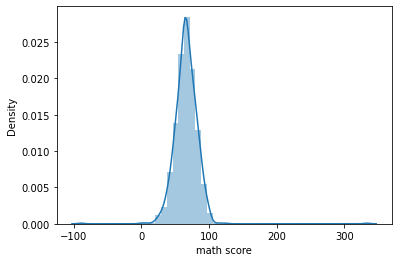

```python
sns.distplot(df['math score'])
```

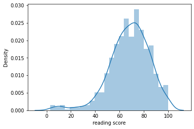

```python
sns.distplot(df['reading score'])
```

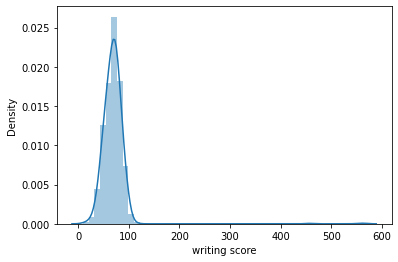

```python
sns.distplot(df['writing score'])
```

### 2. Scan all numeric variables for outliers. If there are outliers, use any of the suitable techniques to deal with them

```python
df.info()
```

```
<class 'pandas.core.frame.DataFrame'>
RangeIndex: 1000 entries, 0 to 999
Data columns (total 8 columns):
 #   Column                       Non-Null Count  Dtype
---  ------                       --------------  -----
 0   gender                       1000 non-null   object
 1   race/ethnicity               1000 non-null   object
 2   parental level of education  1000 non-null   object
 3   lunch                        1000 non-null   object
 4   test preparation course      1000 non-null   object
 5   math score                   1000 non-null   float64
 6   reading score                1000 non-null   float64
 7   writing score                1000 non-null   float64
dtypes: float64(3), object(5)
memory usage: 62.6+ KB
```

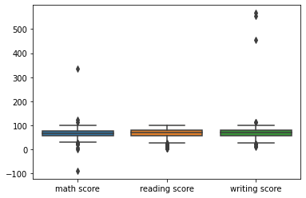

```python
sns.boxplot(data=df)  ## Outliers in Numerical Columns
```

```python
math_score = df['math score'].values
math_score = np.sort(math_score)
math_score_Q1 = math_score[250]
math_score_Q2 = math_score[500]
math_score_Q3 = math_score[750]
math_score_Q1,math_score_Q2,math_score_Q3
```

```
(57.0, 66.0, 76.0)
```

```python
Q1 = int((math_score.size +1) * 1/4)     # lower quartile
Q2 = int((math_score.size +1) * 2/4)     # middle quartile
Q3 = int((math_score.size +1) * 3/4)     # upper quartile
math_score[Q1], math_score[Q2], math_score[Q3]
```

```
(57.0, 66.0, 76.0)
```

```python
Q1 = df.quantile(0.25)
Q3 = df.quantile(0.75)

Q1, Q3
```

```
(math score       57.0
 reading score    58.0
 writing score    58.0
 Name: 0.25, dtype: float64,
 math score       76.0
 reading score    79.0
 writing score    79.0
 Name: 0.75, dtype: float64)
```

```python
IQR = Q3 - Q1
IQR
```

```
math score       19.0
reading score    21.0
writing score    21.0
dtype: float64
```

```python
high = Q3 + 1.5 * IQR
low = Q1 - 1.5 * IQR

high, low
```

```
(math score       104.5
 reading score    110.5
 writing score    110.5
 dtype: float64,
 math score       28.5
 reading score    26.5
 writing score    26.5
 dtype: float64)
```

```python
df[((df<low)|(df>high)).any(axis=1)]    # rows with outliers
```

|  | gender | race/ethnicity | parental level of education | lunch | test preparation course | math score | reading score | writing score |
| --- | --- | --- | --- | --- | --- | --- | --- | --- |
| 18 | male | group C | master's degree | free/reduced | completed | 66.0 | 22.0 | 46.0 |
| 19 | female | group C | associate's degree | free/reduced | none | 66.0 | 22.0 | 61.0 |
| 20 | male | group D | high school | standard | none | 66.0 | 12.0 | 63.0 |
| 21 | female | group B | some college | free/reduced | completed | 66.0 | 12.0 | 70.0 |
| 22 | male | group D | some college | standard | none | 66.0 | 13.0 | 53.0 |
| 23 | female | group C | some high school | standard | none | 66.0 | 14.0 | 69.0 |
| 24 | male | group D | bachelor's degree | free/reduced | completed | 74.0 | 9.0 | 80.0 |
| 25 | male | group A | master's degree | free/reduced | none | 73.0 | 8.0 | 72.0 |
| 26 | male | group B | some college | standard | none | 69.0 | 7.0 | 55.0 |
| 27 | female | group C | bachelor's degree | standard | none | 67.0 | 6.0 | 75.0 |
| 28 | male | group C | high school | standard | none | 70.0 | 4.0 | 69.0 |
| 29 | female | group D | master's degree | standard | none | 62.0 | 3.0 | 75.0 |
| 30 | female | group D | some college | standard | none | 69.0 | 5.0 | 74.0 |
| 31 | female | group B | some college | standard | none | 63.0 | 6.0 | 61.0 |
| 33 | male | group D | some college | standard | none | 40.0 | 22.0 | 38.0 |
| 34 | male | group E | some college | standard | none | 66.0 | 11.0 | 82.0 |
| 35 | male | group E | associate's degree | standard | completed | 81.0 | 11.0 | 79.0 |
| 36 | female | group D | associate's degree | standard | none | 74.0 | 12.0 | 83.0 |
| 37 | female | group D | some high school | free/reduced | none | 50.0 | 12.0 | 59.0 |
| 59 | female | group C | some high school | free/reduced | none | 0.0 | 17.0 | 10.0 |
| 76 | male | group E | some high school | standard | none | 30.0 | 26.0 | 22.0 |
| 91 | male | group C | high school | free/reduced | none | 27.0 | 34.0 | 36.0 |
| 145 | female | group C | some college | free/reduced | none | 22.0 | 39.0 | 33.0 |
| 327 | male | group A | some college | free/reduced | none | 28.0 | 23.0 | 19.0 |
| 338 | female | group B | some high school | free/reduced | none | 24.0 | 38.0 | 27.0 |
| 363 | female | group D | some high school | free/reduced | none | 27.0 | 34.0 | 32.0 |
| 420 | female | group C | associate's degree | free/reduced | completed | 113.0 | 93.0 | 93.0 |
| 431 | female | group C | high school | standard | none | 123.0 | 72.0 | 70.0 |
| 456 | female | group D | bachelor's degree | standard | none | -89.0 | 89.0 | 89.0 |
| 459 | male | group B | high school | standard | completed | 72.0 | 65.0 | 112.0 |
| 465 | female | group C | some college | standard | none | 84.0 | 87.0 | 114.0 |
| 466 | female | group D | associate's degree | free/reduced | none | 26.0 | 31.0 | 38.0 |
| 474 | female | group B | associate's degree | standard | completed | 334.0 | 90.0 | 91.0 |
| 542 | female | group C | associate's degree | standard | none | 81.0 | 77.0 | 455.0 |
| 591 | male | group A | some high school | standard | none | 71.0 | 62.0 | 567.0 |
| 596 | male | group B | high school | free/reduced | none | 30.0 | 24.0 | 15.0 |
| 651 | female | group A | high school | standard | completed | 68.0 | 80.0 | 554.0 |
| 787 | female | group B | some college | standard | none | 19.0 | 38.0 | 32.0 |
| 842 | female | group B | high school | free/reduced | completed | 23.0 | 44.0 | 36.0 |
| 980 | female | group B | high school | free/reduced | none | 8.0 | 24.0 | 23.0 |

```python
df = df[~((df<low)|(df>high)).any(axis=1)]
```

```python
df.shape
```

```
(960, 8)
```

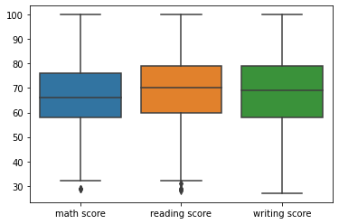

```python
sns.boxplot(data=df)
```

### Convert Categorical Columns to Quantitative Values

```python
categorical_cols = df.select_dtypes(include=['object'])
```

```python
categorical_dummies = pd.get_dummies(categorical_cols)
categorical_dummies
```

|  | gender_female | gender_male | race/ethnicity_group A | race/ethnicity_group B | race/ethnicity_group C | race/ethnicity_group D | race/ethnicity_group E | parental level of education_associate's degree | parental level of education_bachelor's degree | parental level of education_high school | parental level of education_master's degree | parental level of education_some college | parental level of education_some high school | lunch_free/reduced | lunch_standard | test preparation course_completed | test preparation course_none |
| --- | --- | --- | --- | --- | --- | --- | --- | --- | --- | --- | --- | --- | --- | --- | --- | --- | --- |
| 0 | 1 | 0 | 0 | 1 | 0 | 0 | 0 | 0 | 1 | 0 | 0 | 0 | 0 | 0 | 1 | 0 | 1 |
| 1 | 1 | 0 | 0 | 0 | 1 | 0 | 0 | 0 | 0 | 0 | 0 | 1 | 0 | 0 | 1 | 1 | 0 |
| 2 | 1 | 0 | 0 | 1 | 0 | 0 | 0 | 0 | 0 | 0 | 1 | 0 | 0 | 0 | 1 | 0 | 1 |
| 3 | 0 | 1 | 1 | 0 | 0 | 0 | 0 | 1 | 0 | 0 | 0 | 0 | 0 | 1 | 0 | 0 | 1 |
| 4 | 0 | 1 | 0 | 0 | 1 | 0 | 0 | 0 | 0 | 0 | 0 | 1 | 0 | 0 | 1 | 0 | 1 |
| ... | ... | ... | ... | ... | ... | ... | ... | ... | ... | ... | ... | ... | ... | ... | ... | ... | ... |
| 995 | 1 | 0 | 0 | 0 | 0 | 0 | 1 | 0 | 0 | 0 | 1 | 0 | 0 | 0 | 1 | 1 | 0 |
| 996 | 0 | 1 | 0 | 0 | 1 | 0 | 0 | 0 | 0 | 1 | 0 | 0 | 0 | 1 | 0 | 0 | 1 |
| 997 | 1 | 0 | 0 | 0 | 1 | 0 | 0 | 0 | 0 | 1 | 0 | 0 | 0 | 1 | 0 | 1 | 0 |
| 998 | 1 | 0 | 0 | 0 | 0 | 1 | 0 | 0 | 0 | 0 | 0 | 1 | 0 | 0 | 1 | 1 | 0 |
| 999 | 1 | 0 | 0 | 0 | 0 | 1 | 0 | 0 | 0 | 0 | 0 | 1 | 0 | 1 | 0 | 0 | 1 |

960 rows × 17 columns

```python
df = df.drop(list(categorical_cols.columns), axis=1)
df = pd.concat([categorical_dummies, df], axis=1)
```

```python
df.shape
```

```
(960, 20)
```

```python
df.info()
```

```
<class 'pandas.core.frame.DataFrame'>
Int64Index: 960 entries, 0 to 999
Data columns (total 20 columns):
 #   Column                                          Non-Null Count  Dtype
---  ------                                          --------------  -----
 0   gender_female                                   960 non-null    uint8
 1   gender_male                                     960 non-null    uint8
 2   race/ethnicity_group A                          960 non-null    uint8
 3   race/ethnicity_group B                          960 non-null    uint8
 4   race/ethnicity_group C                          960 non-null    uint8
 5   race/ethnicity_group D                          960 non-null    uint8
 6   race/ethnicity_group E                          960 non-null    uint8
 7   parental level of education_associate's degree  960 non-null    uint8
 8   parental level of education_bachelor's degree   960 non-null    uint8
 9   parental level of education_high school         960 non-null    uint8
 10  parental level of education_master's degree     960 non-null    uint8
 11  parental level of education_some college        960 non-null    uint8
 12  parental level of education_some high school    960 non-null    uint8
 13  lunch_free/reduced                              960 non-null    uint8
 14  lunch_standard                                  960 non-null    uint8
 15  test preparation course_completed               960 non-null    uint8
 16  test preparation course_none                    960 non-null    uint8
 17  math score                                      960 non-null    float64
 18  reading score                                   960 non-null    float64
 19  writing score                                   960 non-null    float64
dtypes: float64(3), uint8(17)
memory usage: 45.9 KB
```

```python
df
```

|  | gender_female | gender_male | race/ethnicity_group A | race/ethnicity_group B | race/ethnicity_group C | race/ethnicity_group D | race/ethnicity_group E | parental level of education_associate's degree | parental level of education_bachelor's degree | parental level of education_high school | parental level of education_master's degree | parental level of education_some college | parental level of education_some high school | lunch_free/reduced | lunch_standard | test preparation course_completed | test preparation course_none | math score | reading score | writing score |
| --- | --- | --- | --- | --- | --- | --- | --- | --- | --- | --- | --- | --- | --- | --- | --- | --- | --- | --- | --- | --- |
| 0 | 1 | 0 | 0 | 1 | 0 | 0 | 0 | 0 | 1 | 0 | 0 | 0 | 0 | 0 | 1 | 0 | 1 | 72.0 | 72.0 | 74.0 |
| 1 | 1 | 0 | 0 | 0 | 1 | 0 | 0 | 0 | 0 | 0 | 0 | 1 | 0 | 0 | 1 | 1 | 0 | 66.0 | 90.0 | 88.0 |
| 2 | 1 | 0 | 0 | 1 | 0 | 0 | 0 | 0 | 0 | 0 | 1 | 0 | 0 | 0 | 1 | 0 | 1 | 90.0 | 95.0 | 93.0 |
| 3 | 0 | 1 | 1 | 0 | 0 | 0 | 0 | 1 | 0 | 0 | 0 | 0 | 0 | 1 | 0 | 0 | 1 | 47.0 | 57.0 | 44.0 |
| 4 | 0 | 1 | 0 | 0 | 1 | 0 | 0 | 0 | 0 | 0 | 0 | 1 | 0 | 0 | 1 | 0 | 1 | 76.0 | 78.0 | 75.0 |
| ... | ... | ... | ... | ... | ... | ... | ... | ... | ... | ... | ... | ... | ... | ... | ... | ... | ... | ... | ... | ... |
| 995 | 1 | 0 | 0 | 0 | 0 | 0 | 1 | 0 | 0 | 0 | 1 | 0 | 0 | 0 | 1 | 1 | 0 | 88.0 | 99.0 | 95.0 |
| 996 | 0 | 1 | 0 | 0 | 1 | 0 | 0 | 0 | 0 | 1 | 0 | 0 | 0 | 1 | 0 | 0 | 1 | 62.0 | 55.0 | 55.0 |
| 997 | 1 | 0 | 0 | 0 | 1 | 0 | 0 | 0 | 0 | 1 | 0 | 0 | 0 | 1 | 0 | 1 | 0 | 59.0 | 71.0 | 65.0 |
| 998 | 1 | 0 | 0 | 0 | 0 | 1 | 0 | 0 | 0 | 0 | 0 | 1 | 0 | 0 | 1 | 1 | 0 | 68.0 | 78.0 | 77.0 |
| 999 | 1 | 0 | 0 | 0 | 0 | 1 | 0 | 0 | 0 | 0 | 0 | 1 | 0 | 1 | 0 | 0 | 1 | 77.0 | 86.0 | 86.0 |

960 rows × 20 columns

### 3. Apply data transformations on at least one of the variables. The purpose of this transformation should be one of the following reasons: to change the scale for better understanding of the variable, to convert a non-linear relation into a linear one, or to decrease the skewness and convert the distribution into a normal distribution.

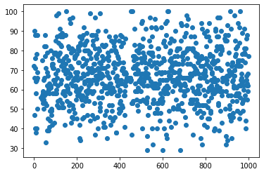

```python
plt.scatter(y = df['math score'], x = df.index)
```

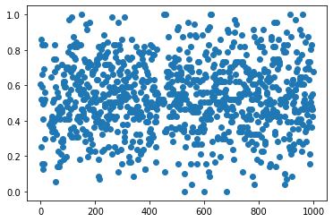

```python
from sklearn.preprocessing import MinMaxScaler
scaler = MinMaxScaler()
df[['math score']] = scaler.fit_transform(df[['math score']])
plt.scatter(y = df['math score'], x = df.index)    # scaled to 0 to 1
```